O R I G I N A L A R T I C L E

A systematic review of the effect of ovarian sex hormones on

stimulant use in females

Shalini Arunogiri<sup>1,2,3</sup>

|

Rose Crossin<sup>4,5</sup>

|

Davinia Rizzo<sup>1,3</sup>

|

Leigh Walker<sup>5</sup>

|

Kelly Ridley<sup>6</sup>

|

Caroline Gurvich<sup>2</sup>

1Monash Addiction Research Centre and

Eastern Health Clinical School, Faculty of

Medicine, Nursing and Health Sciences,

Monash University, Richmond, Victoria,

Australia

2Monash Alfred Psychiatry Research Centre,

Central Clinical School, Faculty of Medicine,

Nursing and Health Sciences, Monash

University and the Alfred Hospital, Melbourne,

Victoria, Australia

3Turning Point, Eastern Health, Richmond,

Victoria, Australia

4Department of Population Health, University

of Otago, Christchurch, New Zealand

5Florey Institute of Neuroscience and Mental

Health, University of Melbourne, Parkville,

Victoria, Australia

6West Australian Country Health Service,

Albany, Western Australia, Australia

Correspondence

Shalini Arunogiri, Monash Alfred Psychiatry

Research Centre, Central Clinical School,

Faculty of Medicine, Nursing and Health

Sciences, Monash University and the Alfred

Hospital, MAPrc, Level 4, 607 St Kilda Road,

Melbourne, VIC 3004 Australia.

Email: shalini.arunogiri@monash.edu

Abstract

Stimulant use disorder is associated with significant global health burden. Despite

evidence for sex differences in the development and maintenance of stimulant use

disorder, few studies have focused on mechanisms underpinning distinct trajectories

in females versus males, including the effect of the ovarian sex hormones estrogen

and progesterone. This review aimed to identify and synthesise the existing preclini-

cal and clinical literature on the effect of ovarian sex hormones on stimulant con-

sumption in females. A systematic search of peer-reviewed literature identified 1593

articles, screened using the following inclusion criteria: (1) adult female humans or

animals, (2) using stimulant drugs, (3) ovarian sex hormones were administered exog-

enously OR were measured in a validated manner and (4) with stimulant consumption

as an outcome measure. A total of 50 studies (3 clinical and 47 preclinical) met inclu-

sion criteria. High-estrogen (low progesterone) phases of the menstrual/estrus cycle

were associated with increased stimulant use in preclinical studies, while there were

no clinical studies examining estrogen and stimulant consumption. Consistent preclin-

ical evidence supported progesterone use reducing stimulant consumption, which

was also identified in one clinical study. The review was limited by inconsistent data

reporting across studies and different protocols across preclinical laboratory para-

digms. Importantly, almost all studies examined cocaine use, with impact on metham-

phetamine use a significant gap in the existing evidence. Given the safety and

tolerability profile of progesterone, further research is urgently needed to address

this gap, to explore the potential therapeutic utility of progesterone as a treatment

for stimulant use disorder.

K E Y W O R D S

addiction, estrogen, progesterone, sex hormones, stimulant use disorder

1

|

INTRODUCTION

Stimulant use disorders (e.g. cocaine and [meth]amphetamine) are

associated with a significant global burden of disease, and metham-

phetamine use has become a major public health concern in North

America, Asia and Oceania.<sup>1</sup>Sex differences are present for all phases

of stimulant use disorders, including initiation, escalation of use and

progression to addiction, maintenance, withdrawal and relapse.<sup>2</sup><sup>–</sup><sup>5</sup>

Rates of stimulant use disorder are currently lower in women than in

men. The global prevalence of amphetamine dependence is estimated

as 0.18% for women and 0.31% for men, and cocaine dependence is

estimated as 0.06% for women and 0.14% for men.<sup>6</sup>However, there

is a growing burden in women, with Australian data suggesting rates

of treatment seeking for stimulant use tripling in women over the past

Received: 3 May 2021

Revised: 23 June 2021

Accepted: 14 July 2021

DOI: 10.1111/adb.13079

Addiction Biology. 2021;26:e13079.

wileyonlinelibrary.com/journal/adb

© 2021 Society for the Study of Addiction

1 of 19

https://doi.org/10.1111/adb.13079

5 years, as compared with a doubling of rates for men.<sup>7</sup>Sex differ-

ences in the trajectories of substance use disorders are observed in

clinical and preclinical models, demonstrating that females escalate

faster from initial use to addiction, take more drugs when addicted

and are more susceptible to stress cue-induced relapse as compared

with males.<sup>8,9</sup>These sex differences have important implications for

treatment, yet understanding has been limited by historical sex bias in

addiction research, which has tended to focus on males in both the

clinical and preclinical literature.<sup>10</sup>There is currently no best-practice

pharmacological treatment for stimulant use disorders.<sup>11,12</sup>Therefore,

an improved understanding of sex differences may present a range of

novel targets for pharmacotherapy.

One biological mechanism that may contribute to the observed

sex-specific differences in stimulant use disorders is the role of ovar-

ian sex hormones, estrogen and progesterone. Both hormones are pri-

marily produced in the ovaries, with circulating levels varying across

the natural menstrual cycle. Estrogen levels peak in the follicular

phase prior to ovulation, and progesterone levels peak in the luteal

phase postovulation and then fall precipitously in the late luteal phase

(Figure 1). Estrogen and progesterone are both known to be neuroac-

tive, including in brain regions associated with reward pathways and

addiction: the nucleus accumbens<sup>13</sup>amygdala,<sup>14</sup>hippocampus<sup>15</sup>

and ventral tegmental area.<sup>16</sup>

Estrogen and progesterone are implicated in human reward

processing via their modulation of dopaminergic transmission. Estro-

gen is thought to enhance dopamine transmission and promote

reward seeking behaviours, potentially exacerbating addictive behav-

iours.<sup>17</sup>Conversely, progesterone may suppress dopaminergic trans-

mission and support the ability to avoid actions that lead to negative

outcomes.<sup>18</sup>Fluctuations in estrogen and progesterone levels across

the menstrual cycle have been associated with fluctuations in avoid-

ance learning; the subjective effects of stimulant drug use and exacer-

bations and relapse of psychiatric disorders, including addiction.<sup>18,19</sup>

There is evidence to suggest that both estrogen and progesterone

may influence addiction in women, with the majority of research

focused on alcohol or smoking.<sup>20</sup><sup>–</sup><sup>22</sup>Yet psychosocial, environmental

and societal factors play a major role in influencing substance consump-

tion in humans, meaning that the biological role of hormones can be dif-

ficult to ascertain within clinical studies. Preclinical models of addiction

can therefore offer critical insights, particularly when synthesised in

parallel with clinical literature. As estrogen and progesterone are com-

mon across mammalian species, comparison of effect is valid between

preclinical (e.g. rat, mouse and monkey) and clinical models, and preclin-

ical studies can be used to explore sex differences in addiction<sup>23</sup>(See

Table 1). Preclinical experiments also have the advantage of enabling

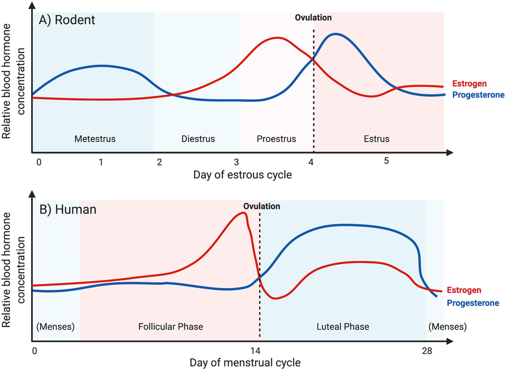

FIGURE 1

Phases of the menstrual cycle

with relative levels of estrogen and progesterone,

when free-cycling in (A) rodents and (B) humans

TABLE 1

Preclinical and clinical terminology across phases of

addiction

Clinical

terminology

Preclinical

terminology

Description

Initiation

Acquisition

The transition from initial drug

exposure to the development

of stable patterns of drug

intake

Maintenance

Maintenance

Stable patterns of drug intake

over time

Motivation

Motivation

The effort demonstrated to

acquire the drug, or the

incentive value of the drug

Escalation

Escalation

The transition from stable to

pathological intake

Withdrawal

Extinction

The cessation of drug use, in

the presence or absence or

physiological dependence

Relapse

Reinstatement

Responding following a cue or

stimulus, after a period of

nonconsumption

2 of 19

ARUNOGIRI ET AL.

analysis of the phases of addiction,<sup>23,24</sup>which can be related to pro-

gression of drug use into dependence, and to DSM-5 criteria for sub-

stance use disorders. Conditioned place preference (CPP) and self-

administration are two of the most commonly used paradigms in pre-

clinical addiction research and can be used to examine clinically rele-

vant aspects of addiction.<sup>25</sup>The CPP paradigm is a form of Pavlovian

conditioning, used to create an association between a drug cue and

context, which can then be used to measure ‘drug-seeking’ or condi-

tioned reward in the absence of drug administration, and is relevant to

acquisition, maintenance, extinction and reinstatement behaviours.<sup>25</sup>

In contrast, self-administration paradigms involve the direct administra-

tion of a drug following a behaviour (response) from the animal such as

a lever press and can be used to model all phases of addiction<sup>25</sup>with a

high degree of validity. Self-administration models can measure both

the amount of a drug consumed and the responses emitted in order to

obtain the drug, as the outcome variables.

Although individual pilot studies<sup>26</sup><sup>–</sup><sup>28</sup>in the clinic suggest that

progesterone may impact on stimulant use, no previous reviews have

systematically examined the evidence for the role of female sex hor-

mones on outcomes relevant to stimulant use disorders. Developing

an understanding of the neurobiological mechanisms underpinning

sex-specific differences in addiction is essential to identify sex-specific

treatment targets; thus, we aimed to synthesise the extant literature

across both preclinical and clinical research. The inclusion criteria

were intentionally broad due to a paucity of studies in this area, and

for completeness, we included all phases of addiction and experimen-

tal paradigms, to highlight priority areas for future research. This sys-

tematic review aimed to answer the following research question:

What are the effects of female sex hormones (administered or

endogenous fluctuations as part of a menstrual cycle) on the use and

consumption of stimulant drugs (cocaine, amphetamine, methamphet-

amine, 3,4-Methylenedioxymethamphetamine (MDMA) and ecstasy)

by adult human women and female animals.

2

|

MATERIALS AND METHODS

The systematic review was undertaken following the Preferred Reporting

Items for the Systematic Reviews and Meta-Analysis (PRISMA) guide-

lines<sup>29</sup>(See Supporting Information Table S1 for PRISMA Checklist).

The

systematic

review

protocol

was

preregistered

on

the

PROSPERO International Prospective Register of Systematic Reviews

(CRD42019133131)

prior

to

study

screening

and

selection

(See

Supporting Information Data S2 for PROSPERO review protocol). Stud-

ies were included if they met the following criteria: (1) female sex hor-

mones or menstrual cycle was measured in a standardised manner

AND/OR sex hormones were administered to participants AND (2) stim-

ulant use of participants was measured in a standardised manner (See

Table 2 for detailed inclusion criteria). The criteria therefore only included

studies where hormones were the intervention, and correlates of stimu-

lant use were the outcome of interest; studies where the opposite was

the case were excluded. We did not include studies that focused on how

hormones affected subjective drug responses or drug-liking.

Electronic searches were performed on the following four

databases—MEDLINE

(OVID),

EMBASE,

Web

of

Science

and

PsycINFO—from the earliest dates available on 5 January 2019. The

search strategy combined three concepts: (i) female participants,

(ii) menstrual cycle and/or female sex hormones and (iii) markers of

use of stimulant substances. Search terms were refined in consulta-

tion with a medical librarian. Search terms for participants included

WOMAN, WOMEN and FEMALE; search terms for Menstrual cycle

and

associated

hormones

included

MENSTRUAL

CYCLE,

TABLE 2

Detailed study inclusion and exclusion criteria

Criteria

Inclusion/exclusion

Language

Any language; no language restrictions

Study design

Inclusion

•

Clinical or preclinical

•

Randomised controlled trials

•

Experimental/interventional-administration of

hormones within lab settings

•

Observational: cross-sectional or cohort

studiesExclusion

•

Literature review or meta-analysis

•

Qualitative study

•

Opinion piece

•

Commentary

•

Editorial

Participants

•

Clinical: adult females (>18 years) using

stimulant drugs

•

Preclinical: no restriction on species, including

mice (C57BL/CD-1), rats (Wistar, Long Evans,

Sprague-Dawley, Fischer), monkeys

(Cynomolgus, Rhesus)

•

Excluded: participants using other substances

where stimulant use was not measured and

reported separately

Intervention/

exposure

•

Clinical: menstrual cycle or changes in sex

hormones were measured using a validated or

standardised tool or biological assay (e.g. Hair/

Saliva Luteinising Hormone levels/2D:4D ratio/

self-report of menstrual cycle) OR gonadal

hormones were administered to participants

•

Preclinical: animal subjects will have had their

ovulation cycle measured, have undergone

ovariectomy or have been administered gonadal

hormones, using a validated or standardised tool

or biological assay

•

Excluded: studies focusing on influence of

stimulants on sex hormones

Outcome

measure

The main outcome in this review is stimulant

•<sup>consumption.</sup>

Clinical: stimulant use by participants, as

measured in a validated manner including:

biological measures—hair/saliva/urine measures;

self-report using validated or standardised tool,

for example, timeline Followback method, self-

reported days or amounts of use

•

Preclinical: paradigms based on acquisition,

maintenance, extinction and reinstatement

phases

ARUNOGIRI ET AL.

3 of 19

OVULATION, ESTROGEN, OESTROGEN and PROGESTERONE, and

search terms for stimulant substances included AMPHETAMINES,

METHAMPHETAMINE and COCAINE (See Supporting Information

Data S3 for search strategy for OVID MEDLINE). In databases where

Medical Subject Headings (MESH) or EMTREE terms were available,

terms were exploded and combined using Boolean operators ‘and’

between two concept terms and Boolean operator ‘or’ between

terms from the same concept. No language restrictions were applied

to the search.

Additional references were searched for by screening the refer-

ence list of previous reviews regarding stimulant use and hormones<sup>3</sup><sup>–</sup><sup>5</sup>

and by citation searching key landmark reviews in the subject area.

All articles were imported to an online systematic review software

platform Covidence (Veritas Health Innovation [25]). Duplicates were

screened via title, author, journal and issue. All stages of screening

(title, abstract and full text) and data extraction were undertaken inde-

pendently by a minimum of two authors. Any conflicts or discrepan-

cies regarding study inclusion or data extraction were resolved by

discussion and resolution by the lead author (SA). Information

extracted included: study setting, study population and participant/

subject demographics (age, ethnicity), baseline characteristics, includ-

ing (i) menstrual cycle phase or use of hormone contraceptive and

(ii) drug use (including age of onset, duration of use, days of use, stim-

ulant of use), study design, study methodology, outcome measures

used and details of intervention and/or control.

Data were extracted and synthesised by hormone (estrogen; pro-

gesterone), and by sub-group (preclinical and clinical). The a priori syn-

thesis plan was to conduct a meta-analysis if more than three studies

described a similar outcome, with quantitative synthesis using

standardised mean difference in stimulant consumption as the effect

measure and a random effects model. Included studies did not meet

this requirement so a narrative synthesis was undertaken, utilising a

summary of findings table for each subgroup (preclinical; clinical; by

intervention/condition type), including the nature of the intervention

and a summary of key outcomes and effect size.

Within study risk of bias, assessments were conducted (See

Supporting

Information

Table

S4)

for

preclinical

studies

using

SYRCLE's risk of bias tool<sup>30</sup>and adapted Joanna Briggs Institute Criti-

cal Appraisal tools for quasi-experimental and randomised trials for

clinical studies.<sup>31</sup>

3

|

RESULTS

3.1

|

Screening

A total of 1593 articles were identified following the above search

strategy. The inclusion/exclusion process (See Figure 2) resulted in a

selection of 50 studies, which included 3 human (clinical) studies and

47 animal (preclinical) studies.

3.2

|

Study characteristics

3.2.1

|

Clinical

All the clinical studies (n = 3) examined the effect of progesterone on

cocaine use (see Table 3).

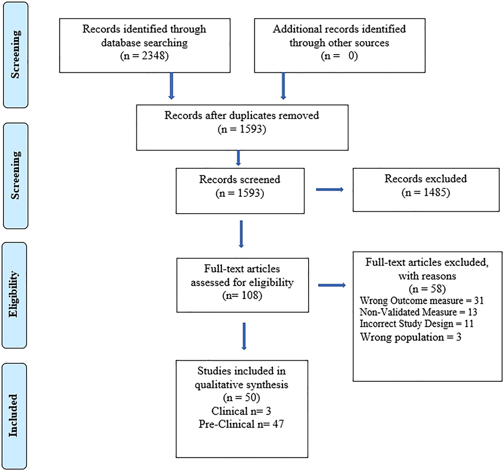

FIGURE 2

Preferred Reporting Items for the

Systematic Reviews and Meta-Analysis (PRISMA)

flow diagram

4 of 19

ARUNOGIRI ET AL.

3.2.2

|

Preclinical

Many of the studies used multiple comparison groups or studied mul-

tiple phases of addiction; for clarity, we are referring to these as ‘com-

parisons’, which may exist within a single published ‘study’—

comprising of 92 comparisons within 47 studies. Of the animal stud-

ies, 16 comparisons were observational, investigating free cycling ani-

mals over the course of the menstrual cycle without hormonal

intervention and/or ovariectomy, while 76 comparisons were inter-

ventional, examining the effect of estrogen, progesterone or combina-

tion administration.

Of the observational studies (Table 4), half investigated acquisi-

tion and/or consumption, and the other half investigated extinction

and/or reinstatement. All observational studies used cocaine as the

experimental stimulant, and rats were the predominant species exam-

ined, with two monkey and one mouse study. Fifteen out of 16 studies

utilised an operant self-administration paradigm.

The interventional studies took three formats; administration

of estrogen (n = 46 comparisons), administration of progesterone

(n = 19 comparisons) and administration of both estrogen and pro-

gesterone in combination (n = 11 comparisons), noting that the

doses and forms of hormones administered were not consistent

(Table 4). Similar to the observational studies, cocaine was the pre-

dominant stimulant utilised, with a small number using metham-

phetamine

or

amphetamine,

while

rats

were

the

predominant

species. Study paradigms included both CPP and operant self-

administration.

3.3

|

Results of studies

3.3.1

|

Clinical studies

Two human studies looked at the effect of oral progesterone on the

effects of cocaine in adult females in an experimental laboratory

setting.<sup>26,27</sup>Sofuoglu et al<sup>27</sup>investigated both male and female partici-

pants, while Reed et al<sup>26</sup>included only female subjects. Both used a quasi-

randomised control design within an experimental laboratory setting.

In

terms

of

consumption,

in

both

studies,

there

was

no

difference between progesterone and placebo groups in cocaine self-

administration. Neither study found any differences between active

(progesterone) and placebo groups in terms of the amount of cocaine

self-administered, plasma cocaine concentration or subjective and

objective

effects

of

cocaine

use

(using

the

Cocaine

Effects

Questionnaire or self-reported effects). Reed et al<sup>26</sup>also found no dif-

ferences between participants in cocaine self-administration based on

menstrual cycle phase. Both studies found heart rate and systolic blood

pressure increased with cocaine use, but was not affected by proges-

terone. In the Sofuoglu study, there were no sex differences in treat-

ment effects, with no differences in cocaine administration between

the progesterone versus placebo group in males or females.<sup>27</sup>

Yonkers et al<sup>28</sup>conducted a 12-week double-blind, placebo-

controlled clinical trial, randomising 50 adult postpartum women to

TABLE 3

Study characteristics of clinical studies

Participants

Stimulant

Intervention

Measures

Number

Mean

age (SD)

Setting

Hormone

administered

Method of

administration

Amount

administered

Duration of

administration

Primary

outcome

Secondary

outcome

Sofuoglu

(2004)

27

10 (30%

female)

38.5

(5.7)

Nontreatment

seeking

Cocaine

Progesterone

Oral

400 mg

1 day

Experimental: number of

cocaine self-deliveries

Cocaine effects

questionnaire

Reed

(2011)26

10 (100%

female)

41 (NR)

Nontreatment

seeking

Cocaine

Progesterone

Oral

150 mg

3 days

Experimental: number of

cocaine doses

purchased

Self-reported effects of

cocaine (VAS)

Yonkers

(2014)

28

50 (100%

female)

32 (5.5)

Postpartum (within

12 weeks of

delivery)

Cocaine

Progesterone

Oral

200 mg

12 weeks

Consumption (days of use

per week)

Time to relapse; cocaine

craving questionnaire

Abbreviations: NR, not reported; VAS, visual analogue scale.

ARUNOGIRI ET AL.

5 of 19

TABLE 4

Study characteristics of preclinical studies

Study

(author, date)

Species

Stimulant

Phase

Interventional

Observational

Acquisition

Maintenance

Motivation

Extinction

Reinstatement

Estrogen

Progesterone

Ovariectomy

Estrus

Diestrus

Phase

‘other’

Anker (2007)32

Rats

Cocaine

•

•

•

•

Anker (2009)33

Rats

Cocaine

•

•

Anker (2010b)34

Rats

Cocaine

•

•

Anker (2010a)35

Rats

Cocaine

•

Anker (2012)36

Rats

Cocaine

•

•

Bechard (2018)37

Rats

Cocaine

•

•

•

•

Bleile (2006)38

Rats

Amph.

•

•

•

•

•

•

Bobzean (2014)39

Rats

Cocaine

•

•

•

Caine (2004)40

Rats

Cocaine

•

•

•

Calipari (2017)41

Mice

Cocaine

•

•

•

Carroll (2016)42

Monkey

Cocaine

•

•

•

Chen (2003)43

Mice

MA

•

•

•

Cooper (2013)44

Monkey

Cocaine

•

Doncheck (2018)45

Rats

Cocaine

•

•

•

•

Feltenstein (2007)46

Rats

Cocaine

•

•

•

•

Feltenstein (2009)47

Rats

Cocaine

•

•

•

•

•

Feltenstein (2011)48

Rats

Cocaine

•

•

•

•

Grimm (1997)49

Rats

Cocaine

•

•

•

Holtz (2012)50

Rats

MA

•

•

Hu (2004)51

Rats

Cocaine

•

•

•

Hu (2008)52

Rats

Cocaine

•

•

•

•

Jackson (2006)53

Rats

Cocaine

•

•

•

•

Kantak (2007)54

Rats

Cocaine

•

•

•

Kerstetter (2008)55

Rats

Cocaine

•

•

•

•

Kerstetter (2012)56

Rats

Cocaine

•

•

•

•

•

Kippin (2005)57

Rats

Cocaine

•

•

•

Kucerova (2009)58

Rats

MA

•

•

•

Larson (2005)59

Rats

Cocaine

•

•

•

•

•

Larson (2007a)60

Rats

Cocaine

•

•

•

Larson (2007b)61

Rats

Cocaine

•

•

•

•

•

Lynch (2000)62

Rats

Cocaine

•

•

•

6 of 19

ARUNOGIRI ET AL.

TABLE 4

(Continued)

Study

(author, date)

Species

Stimulant

Phase

Interventional

Observational

Acquisition

Maintenance

Motivation

Extinction

Reinstatement

Estrogen

Progesterone

Ovariectomy

Estrus

Diestrus

Phase

‘other’

Lynch (2001)63

Rats

Cocaine

•

•

•

Lynch (2005)64

Rats

Cocaine

•

•

•

•

Mello (2008)65

Monkey

Cocaine

•

•

Mello (2011)66

Monkey

Cocaine

•

•

•

Perry (2013)67

Rats

Cocaine

•

•

•

•

•

Ramoa (2013)68

Rats

Cocaine

•

•

•

•

•

Ramoa (2014)69

Rats

Cocaine

•

•

•

•

•

Russo (2003)70

Rats

Cocaine

•

•

•

Russo (2008)71

Rats

Cocaine

•

•

•

Segarra (2014)72

Rats

Cocaine

•

•

•

Silverman (2007)73

Rats

Amph

•

•

•

•

Swalve (2016)74

Rats

Cocaine

•

•

Twining (2013)75

Rats

Cocaine

•

•

•

Yang (2007)76

Rats

Cocaine

•

•

•

•

•

Zhao (2010)77

Rats

Cocaine

•

•

•

•

Zlebnik (2014)78

Rats

Cocaine

•

•

ARUNOGIRI ET AL.

7 of 19

either progesterone (100 mg twice daily, micro-ionised progesterone

capsules) or placebo. Women were followed up for 3 months in an

outpatient setting. Primary outcomes included frequency and amount

of cocaine use and time to relapse. Progesterone had a small, but sta-

tistically significant, decrease in the likelihood of cocaine use per week

in comparison to placebo (RR = 1�19; 95% confidence interval (CI)

= 1�05 to 1�36; p < 0�01); as well as time to relapse (Hazard

Ratio = 4�71;

95%

CI = 1�09–20�47;

p = 0�05).

There

were

no

significant between-group differences in the number of positive urine

screens, nor cocaine craving scores.

3.3.2

|

Physiological and psychological tolerability

In terms of safety and tolerability, there were no differences in

adverse events between placebo and active (progesterone) groups

in any of the included studies. Both Reed<sup>26</sup>and Sofuoglu<sup>27</sup>measured

TABLE 5a

Outcomes—preclinical observational studies

Study

Stimulant<sup>a</sup>

Species<sup>b</sup>

Dose

Paradigm<sup>c</sup>

Outcome

Acquisition phase

Feltenstein (2007)<sup>46</sup>

C

R

N/A

SA

Females in estrus showed greater responding than nonestrus

females

Maintenance phase

Calipari (2017)<sup>41</sup>

C

M

N/A

CPP

Increased CPP in females conditioned during proestrus/estrus,

compared with those conditioned during dioestrus

Feltenstein (2009)<sup>47</sup>

C

R

N/A

SA

Increased consumption during proestrus compared with

diestrus and estrus

Kantak (2007)<sup>54</sup>

C

R

N/A

SA

Decreased consumption in estrus than metestrus-diestrus at

3 mg/kg dose cocaine, with no effect of cycle at lower

cocaine doses

Carroll (2016)<sup>42</sup>

C

Mo

N/A

SA

Increased cocaine consumption during follicular phase than

the luteal phase

Cooper (2013)<sup>44</sup>

C

Mo

N/A

SA

No effect of menstrual cycle on cocaine consumption

Kerstetter (2012)<sup>56</sup>

C

R

N/A

SA

No effect of menstrual cycle on choice of cocaine over food

Lynch (2000)<sup>62</sup>

C

R

N/A

SA

Females in estrus showed increased responding at high doses

of cocaine (2.4 mg/kg) and decreased responding for low

dose cocaine (0.3 mg/kg) compared with metestrus/

dioestrus but not proestrus

Extinction phase

Feltenstein (2007)<sup>46</sup>

C

R

N/A

SA

Females in estrus showed greater responding than nonestrus

females

Kerstetter (2008)<sup>55</sup>

C

R

N/A

SA

Females in estrus showed greater responding than nonestrus

females after 1- to 180-day withdrawal

Reinstatement phase

Bechard (2018)<sup>37</sup>

C

R

N/A

SA

Ceftriaxone reduced reinstatement only during met-, di- and

prestrus phases, not during estrus. Those treated with VEH

showed no effect of menstrual phase on reinstatement.

Feltenstein (2011)<sup>48</sup>

C

R

N/A

SA

Females in prestrus had higher levels of responding during

yohimbine+cues reinstatement compared with those in

estrus and diestrus

Feltenstein (2007)<sup>46</sup>

C

R

N/A

SA

Females in estrus showed greater responding than nonestrus

females

Doncheck (2018)<sup>45</sup>

C

R

N/A

SA

Higher responding during reinstatement relative to extinction

was observed in prestrus, compared with other cycle phases

Kerstetter (2008)<sup>55</sup>

C

R

N/A

SA

Females in estrus showed greater responding than nonestrus

females for primed reinstatement but no difference in cue-

reinstatement after 1- to 180-day withdrawal

Kippin (2005)<sup>57</sup>

C

R

N/A

SA

Females in estrus showed greater responding than nonestrus

females for primed reinstatement—this effect was specific

to middle estrus compared with early and late estrus

aStimulant C, cocaine; A, amphetamine; MA: methamphetamine.

bSpecies R, rats; M, mice; Mo, monkey.

cParadigm SA, self-administration; CPP, conditioned place preference.

8 of 19

ARUNOGIRI ET AL.

TABLE 5b

Outcomes preclinical interventional studies—estrogen administration

Study

Stimulant<sup>a</sup>

Species<sup>b</sup>

Dose

Paradigm<sup>c</sup>

Outcome

key

Outcome

Acquisition phase

Jackson (2006)<sup>53</sup>

C

R

5-μg estradiol

SA

"

Significantly increased acquisition

in the E group compared with

VEH

Chen (2003)<sup>43</sup>

M

M

Estradiol 0.47 μg

CPP

"

Significantly increased CPP in the

E group compared with those

administered VEH

Hu (2008)<sup>52</sup>

C

R

1-, 2- and 5-μg estradiol (acute)

and slow release 1.5-mg pellet

SA

"

Significant increase in acquisition,

only in 2-μg group

Hu 2004<sup>51</sup>

C

R

5-μg estradiol

SA

"

E significantly increased

acquisition in ovariectomised

females

Kerstetter 2012<sup>56</sup>

C

R

5-μg estrogen benzoate

SA

/

No effect of OVX or E on number

of days to acquisition

Kucerova (2009)<sup>58</sup>

M

R

0.28 mg/kg estrogen benzoate

SA

/

No significant difference in

acquisition between OVX + E

and OVX - VEH

Larson (2005)<sup>59</sup>

C

R

0.05 mg/kg estradiol benzoate

long-term—65 days

SA

/

No difference between intact,

OVX + VEH or OVX + E to SA

Lynch (2001)<sup>63</sup>

C

R

0.05 mg/kg 17 b-estradiol

benzoate or 1 mg/kg tamoxifen

SA

"

Increased rate of acquisition in

OVX + E compared with OVX

+ VEH. Decreased rate of

acquisition for rats treated with

tamoxifen compared with VEH.

Lynch (2005)<sup>64</sup>

C

R

5-μg 17 b-estradiol benzoate

SA

/

No effect of OVX + E on number

of days to acquire

Perry (2013)<sup>67</sup>

C

R

5, 10 and 15 mg/kg estradiol

benzoate over 3 days for

3 cycles + 5 mg/kg E prior to

test

SA

"

Increased acquisition with E

compared with VEH

Yang (2007)<sup>76</sup>

C

R

5-μg estradiol benzoate

SA

/

No significant differences

between groups

Zhao (2010)<sup>77</sup>

C

R

5-μg estradiol benzoate

SA

/

No difference between OVX + E

and OVX + VEH

Maintenance phase

Hu (2008)<sup>52</sup>

C

R

1-, 2- and 5-μg estradiol (acute)

and slow release 1.5-mg pellet

SA

"

Significant increase in

consumption only in 1- and 2-μg

group

Caine (2004)<sup>40</sup>

C

R

0.1-mg estradiol pellets

SA

/

No significant effect of E on SA

Grimm (1997)<sup>49</sup>

C

R

37 μg/kg estradiol (acute) and

chronic estradiol pellets (no

dose stated)

SA

#

Decrease in consumption

following acute E treatment, no

effect of chronic E replacement

Bobzean (2014)<sup>39</sup>

C

R

5-μg estradiol

CPP

/

Significant increase in CPP at high

dose of cocaine conditioning

with E but decreased at lower

doses

Kerstetter

(2012)<sup>56</sup>

C

R

5-μg estrogen benzoate

SA

"

Intact and OVX + E have

increased preference for

cocaine over food

Kucerova (2009)<sup>58</sup>

M

R

0.28 mg/kg estrogen benzoate

SA

#

Decreased SA in OVX + E

compared with OVX + VEH—

only after METH pre-exposure

Larson (2005)<sup>59</sup>

C

R

0.05 mg/kg estradiol benzoate

long-term - 65 days

SA

/

No difference between intact,

OVX + VEH or OVX + E for

self-administration

(Continues)

ARUNOGIRI ET AL.

9 of 19

TABLE 5b

(Continued)

Study

Stimulant<sup>a</sup>

Species<sup>b</sup>

Dose

Paradigm<sup>c</sup>

Outcome

key

Outcome

Larson (2007b)<sup>61</sup>

C

R

0.05 mg/kg estradiol benzoate

SA

"

OVX + E showed increased

responding compared with

OVX + VEH

Lynch (2005)<sup>64</sup>

C

R

5-μg 17 b-estradiol benzoate

SA

"

OVX + E showed increased self-

administration compared with

OVX + VEH

Mello (2008)<sup>65</sup>

C

Mo

0.0001, 0.001 and 0.01 mg/kg 17

b-estradiol benzoate

SA

/

No effect of E compared with

VEH on self-administration

Perry (2013)<sup>67</sup>

C

R

5, 10 and 15 mg/kg estrodiol

benzoate over 3 days for 3

cycles + 5 mg/kg E prior to test

SA

"

Increased acquisition compared

with VEH (only in females that

were not administered E in

puberty)

Ramoa (2013)<sup>68</sup>

C

R

5-μg estradiol

SA

"

OVX + E have increased SA

compared with OVX + VEH

after extended access

Ramoa (2014)<sup>69</sup>

C

R

5-μg estradiol

SA

"

OVX + E have increased SA

compared with OVX + VEH

after extended access

Russo (2003)<sup>70</sup>

C

R

1-mm 10% estradiol

CPP

/

CPP observed, OVX + E no

different from OVX + VEH

Segarra (2014)<sup>72</sup>

C

R

4-mg 17 b-estradiol implant

CPP

"

OVX + E rats showed greater CPP

compared with OVX + VEH

Segarra (2014)<sup>72</sup>

C

R

0.15 μl/h i.c.v ICI-183 (anti-

estrogen)

CPP

"

ICI-183 blocked CPP

Silverman (2007)<sup>73</sup>

A

R

17 b-estradiol (80 μg/kg)

CPP

"

OVX + E showed increased CPP

compared with OVX + VEH

Silverman (2007)<sup>73</sup>

A

R

17 b-estradiol (80 μg/kg), 1 mg/kg

DPN, 1 mg/kg PTT

CPP

"

OVX + E and OVX + DPN

(diarylpropionitrile- selective Eb

agonist), but not OVX + PTT

(propylpyrazoletriol - selective

Ea agonist) increased CPP

compared with OVX + VEH

Twining (2013)<sup>75</sup>

C

R

0.2 mg/kg estradiol

CPP

/

CPP observed, OVX + E no

different to OVX + VEH

Yang (2007)<sup>76</sup>

C

R

5-μg estrogen benzoate

SA

"

OVX + E showed increased

administration compared with

OVX + VEH (only at high dose

of cocaine [0.75 mg/kg])

Zhao (2010)<sup>77</sup>

C

R

5-μg estradiol benzoate

SA

"

OVX + E showed increased

cocaine administration

compared with OVX + VEH

Motivation phase

Larson (2007b)<sup>61</sup>

C

R

0.05 mg/kg estradiol benzoate

SA

#

OVX + E showed decreased

breakpoint compared with OVX

+ VEH

Lynch (2005)<sup>64</sup>

C

R

5-μg 17 b-estradiol benzoate

SA

"

OVX + E show higher breakpoint

than OVX + VEH in PR

Perry (2013)<sup>67</sup>

C

R

5, 10 and 15 mg/kg estrodiol

benzoate over 3 days for

3 cycles + 5 mg/kg E prior to

test

SA

"

Adult females administered VEH

in puberty and E in adulthood

showed increased motivation

compared with females that

received E in puberty and

adulthood

10 of 19

ARUNOGIRI ET AL.

physiological responses to cocaine and the effects of progesterone.

Heart rate and systolic blood pressure were found to increase with

cocaine use, regardless of concomitant progesterone or phase of the

menstrual cycle. Sofuoglu<sup>27</sup>found that progesterone resulted in lower

diastolic blood pressure when cocaine was co-administered.

Yonkers<sup>28</sup>

and

Sofuoglu<sup>27</sup>

measured

mood

and

mental

health outcomes, using the Edinburgh Postnatal Depression Scale and

the Profile of Mood States scale respectively. Neither study found a

significant difference between groups in terms of mood.

3.4

|

Preclinical studies

3.4.1

|

Observational studies

In total, 16 observational studies were conducted (Table 5a-5b), of

which eight investigated acquisition and consumption, and eight

investigated extinction and reinstatement. All studies used cocaine

as the experimental stimulant, and rats were the predominant

study paradigm, with two monkey and one mouse study. Fifteen

TABLE 5b

(Continued)

Study

Stimulant<sup>a</sup>

Species<sup>b</sup>

Dose

Paradigm<sup>c</sup>

Outcome

key

Outcome

Ramoa (2013)<sup>68</sup>

C

R

5-μg estradiol

SA

"

OVX + E greater breakpoint than

OVX + VEH after extended

access, but not short access

Ramoa (2014)<sup>69</sup>

C

R

5-μg estradiol

SA

"

OVX + E greater breakpoint than

OVX + VEH after extended

access and 14 days abstinence

Extinction phase

Larson (2005)<sup>59</sup>

C

R

0.05 mg/kg estradiol benzoate

long-term (65 days)

SA

/

Enhanced extinction in OVX

+ VEH or OVX + E for first

3 days compared with intact

animals

Twining (2013)<sup>75</sup>

C

R

0.2 mg/kg estradiol

CPP

"

OVX + E enhanced CPP

extinction compared with OVX

+ VEH

Bleile (2006)<sup>38</sup>

A

R

Estradiol 20 μg/kg

CPP

"

E only group spent most time in

drug-paired compartment, and did

not meet criteria for extinction

Reinstatement phase

Anker (2007)<sup>32</sup>

C

R

0.06-mg estradiol

SA

"

Significantly increased

reinstatement responding in the

E group compared with VEH

Doncheck

(2018)<sup>45</sup>

C

R

10 μg/kg estradiol

SA

"

Significant increase in responding

during reinstatement with E but

only when paired with higher

priming dose of cocaine

Larson (2005)<sup>59</sup>

C

R

0.05 mg/kg estradiol benzoate

short term (9 days) or long term

(65 days)

SA

"

Increased primed reinstatement in

OVX + E compared with OVX

+ VEH after short- and long-

term treatments

Larson (2007a)<sup>60</sup>

C

R

Estradiol benzoate (0.05 mg/kg),

1 mg/kg DPN, 1 mg/kg PTT

SA

"

OVX + EB increased

reinstatement compared with

OVX + VEH and OVX + PPT

(ERa agonist). OVX + DPN (ERb

agonist) increased primed

reinstatement compared with

OVX + VEH and OVX + PPT

groups at 5-mg prime dose

Bleile (2006)<sup>38</sup>

A

R

Estrogen benzoate 20 μg/kg

CPP

/

No significant effect of hormone

treatment on reinstatement

under either stress or drug

challenge conditions

aStimulant C, cocaine; A, amphetamine; MA: methamphetamine.

bSpecies R, rats; M, mice; Mo, monkey.

cParadigm SA, self-administration; CPP, conditioned place preference.

ARUNOGIRI ET AL.

11 of 19

TABLE 5c

Outcomes preclinical interventional studies—progesterone administration

Study

Stimulant<sup>a</sup>

Specieas<sup>b</sup>

Dose

Paradigm<sup>c</sup>

Outcome

key

Outcome

Acquisition phase

Russo

(2008)<sup>71</sup>

C

R

500-μg progesterone

CPP

#

P blocked CPP acquisition in intact

females

Yang (2007)<sup>76</sup>

C

R

500-μg progesterone

SA

/

No significant group differences

Chen (2003)<sup>43</sup>

M

M

Progesterone 0.47 μg

CPP

/

No sig difference between VEH and

P

Maintenance phase

Anker

(2012)<sup>36</sup>

C

R

Progesterone 0.5 mg/kg

SA

#

P significantly blocked escalation of

cocaine self-administration but

only in a saccharin-preferring

phenotype

Anker

(2010b)<sup>34</sup>

C

R

Allopregnanolone 15 mg/kg

SA

#

ALLO significantly blocked

escalation of cocaine self-

administration

Larson

(2007b)<sup>61</sup>

C

R

Progesterone 0.5 mg/kg

SA

#

SHAM + P showed decreased

responding compared with OVX

+ VEH OVX + E, OVX E + P and

SHAM + V groups

Mello

(2011)<sup>66</sup>

C

Mo

Progesterone 0.1, 0.2 and 0.3 mg/

kg

SA

#

Dose-related decrease in cocaine

self-administration following

administration of P

Russo

(2003)<sup>70</sup>

C

R

3 mm 100% progesterone

CPP

#

CPP attenuated by P

Russo

(2008)<sup>71</sup>

C

R

500-μg progesterone

CPP

#

P attenuated CPP in intact females

Yang (2007)<sup>76</sup>

C

R

500-μg progesterone

SA

/

No difference in OVX + P and

OVX + VEH

Motivation phase

Larson

(2007b)<sup>61</sup>

C

R

Progesterone 0.5 mg/kg

SA

#

SHAM + P showed decreased

breakpoint compared with

OVX - VEH in PR

Extinction phase

Bleile (2006)<sup>38</sup>

A

R

Progesterone 100 μg/kg

CPP

#

P group spent least time in drug-

paired compartment

Reinstatement phase

Feltenstein

(2009)<sup>47</sup>

C

R

Progesterone 2 mg/kg

SA

#

Significantly decreased

reinstatement in the P group but

only in animals in estrus, not

prestrus or diestrus

Holtz (2012)<sup>50</sup>

M

R

Allopregnanolone 15 mg/kg

SA

#

ALLO significantly decreased

meth-primed responding

Anker

(2010a)<sup>35</sup>

C

R

Allopregnanolone 15 mg/kg

SA

#

ALLO significantly decreased

yohimbine-induced

reinstatement

Anker

(2009)<sup>33</sup>

C

R

Allopregnanolone 15 and 30 mg/

kg, progesterone 0.5 mg/kg

SA

#

Significantly decreased

reinstatement in the P and

ALLO groups (effect greater

with ALLO)

Swalve

(2016)<sup>84</sup>

C

R

Progesterone 0.5 mg/kg

SA

#

Decreased cue-reinstatement in P

compared with VEH

12 of 19

ARUNOGIRI ET AL.

out of 16 studies utilised a self-administration paradigm. These

studies primarily investigated free-cycling animals over the course

of the menstrual cycle, without hormonal intervention and/or

ovariectomy. When considering the acquisition/consumption stud-

during phases of high estrogen (proestrus, estrus or the follicular

phase), though these effects showed some dependence on cocaine

dose.<sup>54,62</sup>Two studies found no effect of menstrual cycle phase

on either cocaine consumption<sup>44</sup>or on choice of cocaine over food

reward.<sup>56</sup>In contrast, studies investigating extinction or reinstate-

ment were relatively consistent in finding that cocaine responding

trus

in

those

utilising

the

four-period

menstrual

cycle

defini-

tion.<sup>45,46,48,55,57</sup>This included a study,<sup>37</sup>which investigated the

effects of ceftriaxone (an antibiotic) on reinstatement, and found

that ceftriaxone only attenuated reinstatement only during the

met-, di- and pro-estrus phases, not during estrus.

3.4.2

|

Interventional studies

The interventional studies took three formats: administration of estro-

gen, administration of progesterone and administration of both hor-

mones,

noting

that

the

doses

and

formulations

of

hormones

a small number using methamphetamine or amphetamine, and rats

were the predominant species. Study paradigms included both CPP

and self-administration.

All studies are summarised in Tables 5b-5d, with examples

cited in this text. The effects of estrogen treatment were inconsis-

tent, generally observed to either increase or have no effect on

stimulant

acquisition

and

maintenance,

in

both

the

self-

administration (e.g. Jackson<sup>53</sup>and Larson<sup>61</sup>) and CPP paradigms

(e.g. Chen<sup>43</sup>and Bobzean<sup>39</sup>). Two dissenting studies showed that

estrogen treatment decreased responding;<sup>49,58</sup>noting that in the

Grimm<sup>49</sup>study, this effect was only observed with acute estrogen

treatment. Studies investigating the effects of estrogen during

studies of motivation that measured the incentive value of the

drug (as measured by progressive ratio), extinction and reinstate-

ment were more consistent, with the majority of studies (e.g.

Twining<sup>75</sup>and Anker<sup>32</sup>) showing increased responding or CPP with

estrogen treatment compared with vehicle, with only one study<sup>61</sup>

showing the inverse and two studies inconclusive as to effect.<sup>38,59</sup>

The effects of progesterone treatment were also tested in both

self-administration and CPP paradigms, through a range of addiction

phases. In the acquisition and maintenance phase, 7-out-of-10 studies

showed that progesterone treatment, in doses ranging from 0.1–

15 mg/kg, decreased both self-administration (e.g. Anker<sup>36</sup>) and CPP

(e.g. Russo<sup>70</sup>), whereas two studies found no significant effect of pro-

gesterone treatment on acquisition or consumption of stimulants,<sup>43,77</sup>

noting that in both of these studies, the doses of progesterone were

relatively low in comparison to other studies. Progesterone treatment

decreased stimulant consumption in experiments testing motivation,

extinction and reinstatement, with all studies bar two reporting con-

sistent findings. Both Zlebnik<sup>78</sup>and Bleile<sup>38</sup>found no significant effect

of progesterone treatment.

When estrogen and progesterone were administered together,

findings were inconsistent across all paradigms and phases of addic-

tion, though doses were varied. No consistent observations can be

drawn from these studies.

3.4.3

|

Risk of bias assessments

The

results

of

the

risk

of

bias

assessments

for

individual

studies are presented in Appendix S3. Overall, fewer than 10%

of

preclinical

studies

met

the

majority

of

the

risk

of

bias

criteria, suggesting a high risk of bias. Clinical studies generally met

the majority of the risk of bias criteria, suggesting a low risk

of bias.

TABLE 5c

(Continued)

Study

Stimulant<sup>a</sup>

Specieas<sup>b</sup>

Dose

Paradigm<sup>c</sup>

Outcome

key

Outcome

Zlebnik

(2014)<sup>78</sup>

C

R

Progesterone 0.5 mg/kg

SA

/ & #

P alone did not reduce cue-

induced reinstatement, or

primed reinstatement, but did

decrease yohimbine (stress) and

combined cocaine and cue-

induced reinstatement.

Bleile (2006)<sup>38</sup>

A

R

Progesterone 100 μg/kg

CPP

/

No significant effect of P on

reinstatement under either

stress or drug challenge

conditions

aStimulant C: cocaine A: amphetamine M: methamphetamine.

bSpecies R, rats; M, mice; Mo, monkey.

cParadigm SA, self-administration; CPP, conditioned place preference

ARUNOGIRI ET AL.

13 of 19

4

|

DISCUSSION

Our systematic review is the first, to our knowledge, to combine the

results of both preclinical and clinical studies on the relationship

between sex hormones (estrogen and progesterone) and stimulant

use in females.

There were no clinical studies on estrogen and stimulant con-

sumption; likely related to the fact that the preclinical findings were

mixed, but overall, pointed to estrogen having a role in increasing

stimulant use. Increased responding and CPP were observed during

the high-estrogen phases of the menstrual cycle in the majority of

observational ‘free-cycling’ studies, and in line with this, self-

administration and CPP were increased in the majority of interven-

tional studies following estrogen administration. However, results

were more consistent during the extinction and reinstatement phases,

suggesting that estrogen may play a greater role over this period.

TABLE 5d

Outcomes preclinical interventional studies—estrogen and progesterone administration

Study

Stimulant<sup>a</sup>

Species<sup>b</sup>

Dose

Paradigm<sup>c</sup>

Outcome

key

Outcome

Acquisition phase

Jackson

(2006)<sup>53</sup>

C

R

5-μg estradiol with 125-μg

progesterone

SA

/

No significant difference between

VEH and E + P

Bleile

(2006)<sup>38</sup>

A

R

Estradiol benzoate 20 μg/kg and

progesterone 100 μg/kg

CPP

/

Hormone treatment did not influence

the acquisition or magnitude of

CPP

Yang

(2007)<sup>76</sup>

C

R

5 μg estrogen benzoate + 500-μg

progesterone concurrently or

sequentially

SA

/

No differences between OVX + E

+ P compared with OVX + VEH,

OVX + E, OVX + P

Maintenance phase

Larson

(2007b)<sup>61</sup>

C

R

0.05 mg/kg estradiol benzoate and

progesterone 0.5 mg/kg

SA

#

Decreased responding in OVX + E

+ P compared with OVX + E group

Russo

(2003)<sup>70</sup>

C

R

1-mm 10% estradiol and 3-mm 100%

progesterone

CPP

"

E + P significantly increased CPP

score compared with VEH, E alone

and P alone

Silverman

(2007)<sup>73</sup>

A

R

17 b-estradiol (80 μg/kg) + 2.5 mg/kg

progesterone

CPP

"

OV + E + P showed increased CPP

compared with OVX + VEH, but

similar to OVX + E

Yang

(2007)<sup>76</sup>

C

R

5-μg estrogen benzoate and 500-μg

progesterone concurrently or

sequentially

SA

" /

Sequential administration of E + P

increased SA (only at high 0.75 mg/

kg dose) compared with OVX

+ VEH. Concurrent administration

“blocked” significant increase.

Motivation phase

Larson

(2007b)<sup>61</sup>

C

R

0.05 mg/kg estradiol benzoate +

Progesterone 0.5 mg/kg

SA

/

No difference observed between

OVX + E + P and OVX + VEH,

OVX + E, or SHAM

Extinction phase

Bleile

(2006)<sup>38</sup>

A

R

Estradiol benzoate 20 μg/kg and

progesterone 100 μg/kg

CPP

/

E + P did not meet criteria for

extinction

Reinstatement phase

Anker

(2007)<sup>32</sup>

C

R

0.06-mg estradiol and 0.625-mg

progesterone

SA

#

Significantly decreased reinstatement

responding in the E + P group

compared with those administered

E

Bleile

(2006)<sup>38</sup>

A

R

Estradiol benzoate 20 μg/kg and

progesterone 100 μg/kg

CPP

/

No significant effect of hormone

treatment on reinstatement under

either stress or drug challenge

conditions

aStimulant C: cocaine A: amphetamine M: methamphetamine.

bSpecies R, rats; M, mice; Mo, monkey.

cParadigm SA, self-administration; CPP, conditioned place preference.

14 of 19

ARUNOGIRI ET AL.

In contrast, there was a relatively consistent signal from preclini-

cal studies that progesterone impacts stimulant use. This was

observed in the majority of animal studies within the acquisition and

maintenance

phases

when

progesterone

was

administered

at

moderate-higher doses (0.1–15 mg/kg), with a reduction in self-

administration of cocaine, as well as CPP. The role of progesterone

during the extinction and reinstatement phases in preclinical studies

was also strong, with a wide range of progesterone doses showing

decreased reinstatement in a self-administration paradigm.

Within clinical studies, the impact of progesterone on cocaine

consumption was less consistent, with one (out of three) included

studies identifying a difference between active progesterone and pla-

cebo control groups on measures of stimulant use (amount and fre-

quency). Studies were limited by very small sample sizes (n = 10) and

were likely underpowered to detect a true difference.<sup>26,27</sup>Addition-

ally, duration of exposure or treatment may be important, as experi-

mental studies with 1–3 days of administration of progesterone<sup>26,27</sup>

had null findings, compared with statistically significant results within

a 12-week twice-daily dosing regimen.<sup>28</sup>Further, human studies

found progesterone to be generally well tolerated and safe, with no

differences in adverse events between active and placebo groups in

any of the three included studies.<sup>26</sup><sup>–</sup><sup>28</sup>Relevant to this was the short

duration of active treatment, from 1–3 days in the experimental stud-

ies and up to 12 weeks in the only included trial. This suggests that

there is limited evidence on tolerability and adverse effects for

medium- to long-term administration in women with stimulant use

disorder.

While this review focused primarily on stimulant use and mea-

sures of consumption, our findings are consistent with previous

reviews that have identified an impact of progesterone on other cor-

relates of stimulant addiction, including reduction in craving<sup>78</sup>and

modulation of the subjective effect of stimulants.<sup>19,79</sup>

In humans, progesterone-high phases of the menstrual cycle

(i.e. luteal phase) have been associated with decreased susceptibility

to stress and cue-induced craving in cigarette smokers, whereas

women have been found to have greater vulnerability to relapse dur-

ing low-progesterone phases (i.e. follicular phase).<sup>22,80</sup>However, men-

strual cycle phase may be an important factor in influencing

progesterone effect. In a laboratory-based study of administration of

amphetamine to women without a history of substance use, oral pro-

gesterone treatment during the follicular (high oestrogen) phase

enhanced the positive subjective effects of amphetamine, raising the

possibility that the ratio of oestrogen/progesterone may play a role in

the impact of progesterone on stimulants.<sup>81</sup>

In preclinical studies, progesterone has also been found to reduce

impulsive choice (delay discounting) for cocaine<sup>82</sup>and performance

on impulsive action tasks (Go/No Go)<sup>83</sup>in female rats. Further, while

sex differences were not directly compared, several important differ-

ences have been observed between male and female rats following

estradiol or progesterone administration. For example, estradiol

administration

did

not

enhance

acquisition

of

cocaine

self-

administration in castrated male rats at the same dose that is effective

in female rats<sup>53,66</sup>nor influence breakpoint on a PR schedule.<sup>66</sup>

Progesterone

administration

reduced drug-

and

yohimbine/cue-

induced reinstatement of cocaine seeking in male rats in a similar

manner to female counterparts.<sup>74</sup>However, other studies have been

less conclusive, with no effect observed in reinstatement of cocaine

seeking in male rats following progesterone administration.<sup>82</sup>In addi-

tion,

allopregnanolone,

a

progesterone

metabolite,

blocked

yohimbine-induced and drug primed reinstatement of cocaine seeking

in female but not male rats,<sup>32,34</sup>and similarly, drug-induced reinstate-

ment of methamphetamine seeking was reduced by allopregnanolone

in females but not male rats.<sup>40</sup>Suggesting progesterone as a potential

treatment option for stimulant use disorder may be better targeted

towards women.

From

a

mechanistic

perspective,

progesterone

suppresses

E2-mediated

dopaminergic

transmission

in

addiction

behaviour-

relevant brain regions, orbitofrontal and amygdala regions.<sup>84,85</sup>In

addition, GABA agonism may be another explanatory pathway under-

pinning this effect. Allopregnanolone, the active metabolite of proges-

terone, positively modulates GABAA receptors and enhances central

GABA transmission, thereby reinforcing inhibition of drug reward sys-

tems in the brain.<sup>80</sup>This mechanism has been well characterised in

the preclinical literature.<sup>79</sup>In addition, neuroactive steroids, including

progesterone and its active metabolites, have a well-established role

in modulating stress signalling<sup>86</sup>and have been found to attenuate

stress response, reducing both stress and cue-induced craving in ani-

mal and human studies.<sup>80,87</sup>Disordered stress response systems,

which are common in many women with stimulant use disorder who

have experienced trauma, may also be implicated in modulating stress

response to progesterone. The presence of anxiety or PTSD co-

morbidity in women with stimulant use disorder may influence levels

of progesterone and its active metabolites (allopregnanolone and pre-

gnanolone)<sup>88</sup>as well as the ratio of progesterone to allopregnanolone

over the course of the menstrual cycle.<sup>89</sup>In a study of treatment seek-

ing

cocaine-dependent

individuals

(mixed

male/female

sample),

micronised progesterone was used to increase allopregnanolone

levels, and individuals with high levels of allopregnanolone demon-

strated normalised basal and stress response levels of cortisol and

decreased cocaine cravings.<sup>78</sup>Future research will therefore need to

take into account the presence of anxiety, trauma, hyperarousal symp-

toms and baseline stress response in order to refine the profile of

which women are likely to benefit most from progesterone treatment.

Taken together, this suggests that progesterone may offer a

promising avenue for further investigation as an addiction treatment

for women. Benefits of progesterone and its metabolites as a treat-

ment include limited evidence of addiction liability, low cost and high

accessibility in a range of formulations, with the option of repurposing

widely available hormone-based contraceptives.<sup>90,91</sup>Further, there is

already an established academic and clinical knowledge base on the

safety and tolerability profile of synthetic progestins at doses utilised

for contraceptive purposes, with growing data on improved psychiat-

ric side-effect profile associated with natural progestins.<sup>91</sup>Preclinical

and clinical studies focused on the type of progestin utilised, dose

response and treatment duration that would be valuable to inform

dosing protocols in treatment trials.

ARUNOGIRI ET AL.

15 of 19

4.1

|

Limitations

A limitation of this review was our inability to meta-analyse the findings.

Barriers to synthesising the evidence common to both preclinical and

clinical literature include the heterogeneous populations studied, vari-

able progesterone and estrogen doses and variable outcome measures.

The main limitations from the human studies are small number of

studies and overall sample size. The largest clinical study in our review

recruited 50 participants, and this remains the largest study to date,

even across other nonconsumption outcome measures.<sup>80</sup>This is a

critical gap in the existing evidence. In addition, nearly all the preclini-

cal and clinical studies to date have been conducted in cocaine, and

there is very limited evidence on progesterone in other stimulants,

including amphetamine or methamphetamine. The current evidence

does not allow us to determine if these effects are common across all

stimulants or whether there are substance-specific effects. Future

studies comparing cocaine and methamphetamine would be highly

valuable.

Specific to preclinical studies, limitations arose from the data

available and reported, variable experimental paradigms and interven-

tion doses, as well as doses of the stimulants used. The inclusion

criteria for the review were intentionally broad for completeness, but

this limited our ability to synthesise the outcomes across different

paradigms (e.g. CPP; self-administration) where hormones are likely to

have affected these processes differently. Many of the studies pres-

ented results graphically and indicated significance but did not report

the means and a measure of variance. This would have allowed an

attempt at meta-analysis, including subgroup analyses.

Variance in protocols is an issue for the preclinical field more

broadly in which individual paradigms are perfected and continue over

time within laboratory groups. While this enables internal comparison

of findings, it challenges the pooling of data across lab groups and

studies. Fewer than 10% of the included preclinical studies met the

majority of the risk of bias criteria. Several preclinical studies were

conducted and published prior to the availability of guidelines that

guide the assessment of quality and risk of bias; the most widely used

risk of bias tool, SYRCLE, was published in 2014.<sup>92</sup>Consequently,

very few studies reported the minimum data needed to assess study

quality, with only 10 (21%) of the included preclinical studies publi-

shed after the existence of these guidelines. It is difficult to assess the

extent to which this compromises previous findings, but the implica-

tions for future research are clear. Meta-analyses are being increas-

ingly used to guide medical research, and if preclinical studies are to

become part of this evidence base moving forward, it is important for

manuscript and editorial guidelines to reflect the need for studies to

have the minimum data needed to conduct future meta-analysis and

enable study quality assessment.

5

|

CONCLUSIONS

In synthesising the available evidence, this review highlights the prom-

ise of hormone treatments for stimulant use disorder in females.

Progesterone and its metabolites are potential candidates for transla-

tion into clinical settings, at low cost, with limited abuse potential, and

established

safety

and

tolerability

profiles.<sup>90</sup>

Both

translational

and reverse-translational approaches will be critical in addressing the

remaining gaps in evidence. Clinical studies will assist in refining

the target profile of women who may be most likely to benefit; and

this evidence could potentially inform preclinical studies investigating

specific mechanisms underpinning outcomes.

ACKNOWLEDGEMENTS AND FUNDING DISCLOSURES

This work was unfunded and was not supported by any grants

or

sponsors.

Author

LW

is

supported

by

an

NHMRC

grant

GNT#2002830. The content is solely the work of the authors.

AUTHORS CONTRIBUTION

Lead author SA was responsible for the study design and review pro-

tocol, contribution to data analysis and synthesis and write-up of the

manuscript. Authors SA and DR conducted the literature search.

Authors RC, LW, DR, KR and CG contributed to data extraction, data

synthesis and write-up and editing of the manuscript. All authors con-

tributed to the final manuscript.

DATA AVAILABILITY STATEMENT

N/A- This study does not contain any original data.

ORCID

Shalini Arunogiri

https://orcid.org/0000-0002-7667-8868

Rose Crossin

https://orcid.org/0000-0003-1814-1330

Leigh Walker

https://orcid.org/0000-0002-9282-2743

Caroline Gurvich

https://orcid.org/0000-0002-5663-3419

REFERENCES

1. Farrell M, Martin NK, Stockings E, et al. Responding to global stimu-

lant use: challenges and opportunities. The Lancet. 2019;394(10209):

1652-1667.

2. Quinones-Jenab V, Jenab S. Influence of sex differences and gonadal

hormones on cocaine addiction. ILAR Journal/National res Council, Insti

Lab Animal Res. 2012;53(1):14-22.

3. Evans SM, Foltin RW. Does the response to cocaine differ as a func-

tion of sex or hormonal status in human and non-human primates?

Horm Behav. 2010;58(1):13-21.

4. Quinones-Jenab

V,

Jenab

S.

Progesterone

attenuates

cocaine-

induced responses. Horm Behav. 2010;58(1):22-32.

5. Andersen ML, Sawyer EK, Howell LL. Contributions of neuroimaging

to

understanding

sex

differences

in

cocaine

abuse.

Exp

Clin

Psychopharmacol. 2012;20(1):2-15.

6. Degenhardt L, Baxter AJ, Lee YY, et al. The global epidemiology and

burden of psychostimulant dependence: Findings from the Global Bur-

den of Disease Study 2010. Drug Alcohol Depend. 2014;137(1):36-47.

7. Welfare AIoHa. National Drug Strategy Household Survey (NDSHS)

2016—key findings. AIHW: Canberra; 2017.

8. Sinha R, Fox H, Hong KI, Sofuoglu M, Morgan PT, Bergquist KT. Sex

steroid hormones, stress response, and drug craving in cocaine-

dependent women: implications for relapse susceptibility. Exp Clin

Psychopharmacol. 2007;15(5):445-452.

9. Potenza MN, Hong KIA, Lacadie CM, Fulbright RK, Tuit KL, Sinha R.

Neural Correlates of Stress-Induced and Cue-Induced Drug Craving:

16 of 19

ARUNOGIRI ET AL.

Influences of Sex and Cocaine Dependence. Am J Psychiatry. 2012;

169(4):406-414.

10. Sanchis-Segura C, Becker JB. Why we should consider sex (and study

sex differences) in addiction research. Addict Biol. 2016;21(5):995-1006.

11. Chan B, Kondo K, Ayers C, et al. Pharmacotherapy for Stimulant Use

Disorders: A Systematic Review. Washington (DC): Department of

Veterans Affairs (US); 2018.

12. Siefried KJ, Acheson LS, Lintzeris N, Ezard N. Pharmacological Treat-

ment of Methamphetamine/Amphetamine Dependence: A System-

atic Review. CNS Drugs. 2020;1-29.

13. Becker JB. Gender Differences in Dopaminergic Function in Striatum

and Nucleus Accumbens. Pharmacol Biochem Behav. 1999;64(4):

803-812.

14. Shansky RM. Sex differences in amygdala structure and function: From

rodents to humans. Vol 26. Elsevier Science & Technology; 2020.

15. Hillerer KM, Slattery DA, Pletzer B. Neurobiological mechanisms

underlying sex-related differences in stress-related disorders: Effects

of neuroactive steroids on the hippocampus. Front Neuroendocrinol.

2019;55:100796-100825.

16. You C, Vandegrift B, Brodie MS. Ethanol actions on the ventral

tegmental

area:

novel

potential

targets

on

reward

pathway

neurons. (Review)(Report). Psychopharmacology (Berl). 2018;235(6):

1711-1726.

17. Song Z, Yang H, Peckham EM, Becker JB. Estradiol-induced potentia-

tion of dopamine release in dorsal striatum following amphetamine

administration requires estradiol receptors and mGlu5. Eneuro. 2019;

6(1):1-8.

18. Diekhof EK, Korf S, Ott F, Schädlich C, Holtfrerich SK. Avoidance

learning across the menstrual cycle: A conceptual replication. Front

Endocr (Lausanne). 2020;11(231):1-12.

19. Terner JM, de Wit H. Menstrual cycle phase and responses to drugs

of abuse in humans. Drug Alcohol Depend. 2006;84(1):1-13.

20. Franklin TR, Ehrman R, Lynch KG, et al. Menstrual cycle phase at quit

date predicts smoking status in an NRT treatment trial: a retrospec-

tive analysis. J Womens Health. 2008;17(2):287-292.

21. Erol A, Ho AMC, Winham SJ, Karpyak VM. Sex hormones in alcohol

consumption: a systematic review of evidence. Addict Biol. 2019;

24(2):157-169.

22. Wetherill RR, Franklin TR, Allen SS. Ovarian hormones, menstrual

cycle phase, and smoking: a review with recommendations for future

studies. Curr Addict Rep. 2016;3(1):1-8.

23. Carroll ME, Lynch WJ. How to study sex differences in addiction

using animal models. Addict Biol. 2016;21(5):1007-1029.

24. Lynch WJ, Nicholson KL, Dance ME, Morgan RW, Foley PL. Animal

models of substance abuse and addiction: implications for science,

animal welfare, and society. Comp Med. 2010;60(3):177-188.

25. Smith MA. Nonhuman animal models of substance use disorders:

Translational value and utility to basic science. Drug Alcohol Depend.

2020;206:107733-107765.

26. Reed SC, Evans SM, Bedi G, Rubin E, Foltin RW. The effects of oral

micronized progesterone on smoked cocaine self-administration in

women. Horm Behav. 2011;59(2):227-235.

27. Sofuoglu M, Mitchell E, Kosten TR. Effects of progesterone treatment

on cocaine responses in male and female cocaine users. Pharmacol

Biochem Behav. 2004;78(4):699-705.

28. Yonkers KA, Forray A, Nich C, et al. Progesterone for the reduction of

cocaine use in post-partum women with a cocaine use disorder: a ran-

domised,

double-blind,

placebo-controlled,

pilot

study.

Lancet

Psychiatry. 2014;1(5):360-367.

29. Moher D, Liberati A, Tetzlaff J, Altman DG. Reprint--preferred

reporting items for systematic reviews and meta-analyses: the PRI-

SMA statement. Phys Ther. 2009;89(9):873-880.

30. Hooijmans CR, Rovers MM, De Vries RB, Leenaars M, Ritskes-

Hoitinga M, Langendam MW. SYRCLE's risk of bias tool for animal

studies. BMC Med Res Methodol. 2014;14(1):43-52.

31. Tufanaru C, Munn Z, Aromataris E, Campbell J, Hopp L. Chapter 3:

Systematic reviews of effectiveness. Joanna Briggs Inst Reviewer's

Man the Joanna Briggs Insti. 2017. https://doi.org/10.46658/JBIMES-

20-04

32. Anker JJ, Larson EB, Gliddon LA, Carroll ME. Effects of progesterone

on the reinstatement of cocaine-seeking behavior in female rats. Exp

Clin Psychopharmacol. 2007;15(5):472-480.

33. Anker

JJ,

Holtz

NA,

Zlebnik

N,

Carroll

ME.

Effects

of

all-

opregnanolone on the reinstatement of cocaine-seeking behavior in

male and female rats. Psychopharmacology (Berl). 2009;203(1):63-72.

34. Anker JJ, Zlebnik NE, Carroll ME. Differential effects of all-

opregnanolone on the escalation of cocaine self-administration and

sucrose intake in female rats. Psychopharmacology (Berl). 2010;212(3):

419-429.

35. Anker

JJ,

Carroll

ME.

Sex

differences

in

the

effects

of

all-

opregnanolone on yohimbine-induced reinstatement of cocaine seek-

ing in rats. Drug Alcohol Depend. 2010;107(2-3):264-267.

36. Anker JJ, Holtz NA, Carroll ME. Effects of progesterone on escalation

of intravenous cocaine self-administration in rats selectively bred for

high or low saccharin intake. Behav Pharmacol. 2012;23(2):205-210.

37. Bechard AR, Hamor PU, Schwendt M, Knackstedt LA. The effects of

ceftriaxone on cue-primed reinstatement of cocaine-seeking in male

and female rats: estrous cycle effects on behavior and protein expres-

sion in the nucleus accumbens. Psychopharmacology (Berl). 2018;

235(3):837-848.

38. Bleile ME. Female hormonal influences on stress- and drug-induced

reinstatement of extinguished amphetamine-induced conditioned

place preference. Disser Abst Intern: Sec B: The Sci Engin. 2006;

67(2-B).

39. Bobzean SAM, Dennis TS, Perrotti LI. Acute estradiol treatment

affects the expression of cocaine-induced conditioned place prefer-

ence in ovariectomized female rats. Brain Res Bull. 2014;103:49-53.

40. Caine SB, Bowen CA, Yu G, Zuzga D, Negus SS, Mello NK. Effect of

gonadectomy and gonadal hormone replacement on cocaine self-

administration in female and male rats. Neuropsychopharmacology.

2004;29(5):929-942.

41. Calipari E, Juarez B, Morel C, et al. Dopaminergic dynamics underlying

sex-specific cocaine reward processing. Neuropsychopharmacology.

2016;41:S431-S432.

42. Carroll ME, Collins M, Kohl EA, Johnson S, Dougen B. Sex and men-

strual cycle effects on chronic oral cocaine self-administration in

rhesus monkeys: Effects of a nondrug alternative reward. Psychophar-

macology (Berl). 2016;233(15-16):2973-2984.

43. Chen HH, Yang YK, Yeh TL, et al. Methamphetamine-induced condi-

tioned place preference is facilitated by estradiol pretreatment in

female mice. Chin J Physiol. 2003;46(4):169-174.

44. Cooper ZD, Foltin RW, Evans SM. Effects of menstrual cycle phase

on cocaine self-administration in rhesus macaques. Horm Behav.

2013;63(1):105-113.

45. Doncheck EM, Urbanik LA, Debaker MC, et al. 17β-Estradiol Potenti-

ates the Reinstatement of Cocaine Seeking in Female Rats: Role of

the Prelimbic Prefrontal Cortex and Cannabinoid Type-1 Receptors.

Neuropsychopharmacology. 2018;43(4):781-790.

46. Feltenstein MW, See RE. Plasma progesterone levels and cocaine-

seeking in freely cycling female rats across the estrous cycle. Drug

Alcohol Depend. 2007;89(2-3):183-189.

47. Feltenstein MW, Byrd EA, Henderson AR, See RE. Attenuation of

cocaine-seeking

by

progesterone

treatment

in

female

rats.

Psychoneuroendocrinology. 2009;34(3):343-352.

48. Feltenstein MW, Henderson AR, See RE. Enhancement of cue-

induced reinstatement of cocaine-seeking in rats by yohimbine: sex

differences and the role of the estrous cycle. Psychopharmacology

(Berl). 2011;216(1):53-62.

49. Grimm JW, See RE. Cocaine self-administration in ovariectomized

rats is predicted by response to novelty, attenuated by 17-β estradiol,

ARUNOGIRI ET AL.

17 of 19

and associated with abnormal vaginal cytology. Physiol Behav. 1997;

61(5):755-761.

50. Holtz NA, Lozama A, Prisinzano TE, Carroll ME. Reinstatement of

methamphetamine seeking in male and female rats treated with

modafinil and allopregnanolone. Drug Alcohol Depend. 2012;120(1-3):

233-237.

51. Hu M, Crombag HS, Robinson TE, Becker JB. Biological basis of sex

differences

in

the

propensity

to

self-administer

cocaine.

Neuropsychopharmacology. 2004;29(1):81-85.

52. Hu M, Becker JB. Acquisition of cocaine self-administration in ovari-

ectomized female rats: Effect of estradiol dose or chronic estradiol

administration. Drug Alcohol Depend. 2008;94(1-3):56-62.

53. Jackson LR, Robinson TE, Becker JB. Sex differences and hormonal

influences on acquisition of cocaine self-administration in rats.

Neuropsychopharmacology. 2006;31(1):129-138.

54. Kantak KM, Goodrich CM, Uribe V. Influence of sex, Estrous cycle,

and drug-onset age on cocaine self-administration in rats (Rattus

norvegicus). Exp Clin Psychopharmacol. 2007;15(1):37-47.

55. Kerstetter KA, Aguilar VR, Parrish AB, Kippin TE. Protracted time-

dependent increases in cocaine-seeking behavior during cocaine

withdrawal in female relative to male rats. Psychopharmacology (Berl).

2008;198(1):63-75.

56. Kerstetter KA, Ballis MA, Duffin-Lutgen S, Carr AE, Behrens AM,

Kippin TE. Sex Differences in Selecting Between Food and Cocaine

Reinforcement are Mediated by Estrogen. Neuropsychopharmacology.

2012;37(12):2605-2614.

57. Kippin TE, Fuchs RA, Mehta RH, et al. Potentiation of cocaine-primed

reinstatement

of

drug

seeking

in

female

rats

during

estrus.

Psychopharmacology (Berl). 2005;182(2):245-252.

58. Kucerova J, Vrskova D, Sulcova A. Impact of repeated methamphet-

amine pretreatment on intravenous self-administration of the drug in

males and estrogenized or non-estrogenized ovariectomized female

rats. Neuroendocrinology Letters. 2009;30(5):663-670.

59. Larson EB, Roth ME, Anker JJ, Carroll ME. Effect of short-

vs. long-term estrogen on reinstatement of cocaine-seeking behavior

in female rats. Pharmacol Biochem Behav. 2005;82(1):98-108.

60. Larson EB, Carroll ME. Estrogen receptor β, but not α, mediates estro-

gen's

effect

on cocaine-induced

reinstatement of

extinguished

cocaine-seeking

behavior

in

ovariectomized

female

rats.

Neuropsychopharmacology. 2007;32(6):1334-1345.

61. Larson EB, Anker JJ, Gliddon LA, Fons KS, Carroll ME. Effects of

estrogen and progesterone on the escalation of cocaine self-

administration in female rats during extended access. Exp Clin

Psychopharmacol. 2007;15(5):461-471.

62. Lynch WJ, Arizzi MN, Carroll ME. Effects of sex and the estrous cycle

on regulation of intravenously self-administered cocaine in rats.

Psychopharmacology (Berl). 2000;152(2):132-139.

63. Lynch WJ, Roth ME, Mickelberg JL, Carroll ME. Role of estrogen in

the acquisition of intravenously self-administered cocaine in female

rats. Pharmacol Biochem Behav. 2001;68(4):641-646.

64. Lynch WJ, Taylor JR. Decreased motivation following cocaine self-

administration under extended access conditions: Effects of sex and

ovarian hormones. Neuropsychopharmacology. 2005;30(5):927-935.

65. Mello NK, Negus SS, Knudson IM, Kelly M, Mendelson JH. Effects of

estradiol on cocaine self-administration and cocaine discrimination by

female

rhesus

monkeys.

Neuropsychopharmacology.

2008;33(4):

783-795.

66. Mello NK, Knudson IM, Kelly M, Fivel PA, Mendelson JH. Effects of

Progesterone and Testosterone on Cocaine Self-Administration and

Cocaine

Discrimination

by

Female

Rhesus

Monkeys.

Neuropsychopharmacology. 2011;36(11):2187-2199.

67. Perry AN, Westenbroek C, Becker JB. Impact of pubertal and adult

estradiol treatments on cocaine self-administration. Horm Behav.

2013;64(4):573-578.

68. Ramoa CP, Doyle SE, Naim DW, Lynch WJ. Estradiol as a Mechanism

for Sex Differences in the Development of an Addicted Phenotype

following

Extended

Access

Cocaine

Neuropsychopharmacology. 2013;38(9):1698-1705.<sup>Self-Administration.</sup>

69. Ramoa CP. Neurobiological basis for the development of cocaine

addiction in females: Role of estradiol. Disser Abst Intern: Sec B: The

Sci Engin. 2014;74. (12-B[E]):No-Specified

70. Russo SJ, Festa ED, Fabian SJ, et al. Gonadal hormones differentially

modulate cocaine-induced conditioned place preference in male and

female rats. Neuroscience. 2003;120(2):523-533.

71. Russo SJ, Sun WL, Minerly ACE, et al. Progesterone attenuates

cocaine-induced conditioned place preference in female rats. Brain

Res. 2008;1189:229-235.

72. Segarra AC, Torres-Diaz YM, Silva RD, et al. Estrogen receptors medi-

ate estradiol's effect on sensitization and CPP to cocaine in female

rats: Role of contextual cues. Horm Behav. 2014;65(2):77-87.

73. Silverman JL, Koenig JI. Evidence for the involvement of ERβ and

RGS9-2 in 17-β estradiol enhancement of amphetamine-induced

place preference behavior. Horm Behav. 2007;52(2):146-155.

74. Swalve N, Smethells JR, Zlebnik NE, Carroll ME. Sex differences in

reinstatement of cocaine-seeking with combination treatments of

progesterone and atomoxetine. Pharmacol Biochem Behav. 2016;145:

17-23.

75. Twining RC, Tuscher JJ, Doncheck EM, Frick KM, Mueller D. 17β-

Estradiol is necessary for extinction of cocaine seeking in female rats.

Learn Mem. 2013;20(6):300-306.

76. Yang H, Zhao W, Hu M, Becker JB. Interactions among ovarian hor-

mones and time of testing on behavioral sensitization and cocaine

self-administration. Behav Brain Res. 2007;184(2):174-184.

77. Zhao W, Becker JB. Sensitization enhances acquisition of cocaine

self-administration

in

female

rats:

Estradiol

further

enhances

cocaine intake after acquisition. Horm Behav. 2010;58(1):8-12.

78. Zlebnik NE, Saykao AT, Carroll ME. Effects of combined exercise and

progesterone treatments on cocaine seeking in male and female rats.

Psychopharmacology (Berl). 2014;231(18):3787-3798.

79. Milivojevic

V,

Fox

HC,

Sofuoglu

M,

Covault

J,

Sinha

R.

Effects of progesterone stimulated allopregnanolone on craving

and

stress

response

in

cocaine

dependent

men

and

women.

Psychoneuroendocrinology. 2016;65:44-53.

80. Forray A, Sofuoglu M. Future pharmacological treatments for sub-

stance use disorders. Br J Clin Pharmacol. 2014;77(2):382-400.

81. Peltier MR, Sofuoglu M. Role of exogenous progesterone in the treat-

ment of men and women with substance use disorders: a narrative

review. CNS Drugs. 2018;32(5):421-435.

82. Reed SC, Levin FR, Evans SM. The effects of progesterone pre-

treatment on the response to oral D-amphetamine in Women. Horm

Behav. 2010;58(3):533-543.

83. Smethells JR, Swalve NL, Eberly LE, Carroll ME. Sex differences in the

reduction of impulsive choice (delay discounting) for cocaine in rats

with atomoxetine and progesterone. Psychopharmacology (Berl). 2016;

233(15-16):2999-3008.

84. Swalve N, Smethells JR, Carroll ME. Progesterone attenuates impul-

sive action in a Go/No-Go task for sucrose pellets in female and male

rats. Horm Behav. 2016;85:43-47.

85. Hidalgo-Lopez E, Pletzer B. Interactive Effects of Dopamine Baseline

Levels and Cycle Phase on Executive Functions: The Role of Proges-

terone. Front Neurosci. 2017;11(403).

86. Dreher JC, Schmidt PJ, Kohn P, Furman D, Rubinow D, Berman KF.

Menstrual cycle phase modulates reward-related neural function in

women. Proc Natl Acad Sci U S a. 2007;104(7):2465-2470.

87. Anker JJ, Carroll ME. Females are more vulnerable to drug abuse than

males: Evidence from preclinical studies and the role of ovarian hor-

mones. Biological Basis of Sex Differences in Psychopharmacology. Cur-

rent Top Beehav Neurosci. 2011;8:73-96.

18 of 19

ARUNOGIRI ET AL.

88. Rasmusson AM, Pinna G, Paliwal P, et al. Decreased cerebrospinal

fluid allopregnanolone levels in women with posttraumatic stress dis-

order. Biol Psychiatry. 2006;60(7):704-713.

89. Pineles S, Nillni Y, Pinna G, et al. PTSD in women is associated with a

block in conversion of progesterone to the GABAergic neurosteroids

allopregnanolone

and

pregnanolone

measured

in

plasma.

Psychoneuroendocrinology. 2018;93:133-141.

90. Tomaselli G, Vallée M. Stress and drug abuse-related disorders: The

promising therapeutic value of neurosteroids focus on pregnenolone-pro-

gesterone-allopregnanolone pathway. Front Neuroendocrinol. 2019;55.

91. Piette PC. The pharmacodynamics and safety of progesterone. Best

Pract Res Clin Obstet Gynaecol. 2020;69:13-29.

92. Vesterinen HM, Sena ES, Egan KJ, et al. Meta-analysis of data from ani-

mal studies: A practical guide. J Neurosci Methods. 2014;221:92-102.

SUPPORTING INFORMATION

Additional supporting information may be found online in the

Supporting Information section at the end of this article.

How to cite this article: Arunogiri S, Crossin R, Rizzo D,

Walker L, Ridley K, Gurvich C. A systematic review of the

effect of ovarian sex hormones on stimulant use in females.

Addiction Biology. 2021;26(6):e13079. https://doi.org/10.

1111/adb.13079

ARUNOGIRI ET AL.

19 of 19